# How Extreme Weather Influences Perceptions Of Climate Change

BI410 Data Visualization

Ali Carmichael

2025-06-09

## Literature Review

Climate change is no longer a future problem; the effects of increased carbon emissions from human activity are having widespread effects on the environment (NASA). Here are some of the ways climate change is affecting our planet: increased global temperatures, increased drought and decreased snowpack, challenges with global food supply, increased risk to human health, increased sea levels, and overall damage to ecosystems and their organisms (National Oceanic and Atmospheric Administration, NOAA).

Several other similar studies have been done in the past, most of which were conducted in the UK or were focused on the amount of people were willing to pay in tax dollars for climate change policies. One study conducted by Gould et al. sought to understand how extreme weather events influence climate policy support in the U.S. using self-reports and weather data (Gould et al., 2024). Another similar study was done in the UK, where survey data were collected to examine the link between experience with flood disasters and perceptions of climate change (Spence et al., 2011). The National Centers for Environmental Information provides data on severe weather, where you can find detailed information on intense thunderstorms, hailstorms, tornadoes, and blizzards (National Centers for Environmental Information). The National Oceanic and Atmospheric Administration also provides weather data like global temperature, which would be useful to draw patterns from to determine which years saw a higher increase in global temperature that could influence people’s views on climate change (National Oceanic and Atmospheric Administration, NOAA).

The data I will be using is data from the Yale Program on Climate Change Communication & George Mason University Center for Climate Change. It consists of national survey data on public opinions of climate change that contains climate change beliefs and attitudes, risk perceptions, policy preferences, and information acquisition behaviors from 2008-2023, found here: https://osf.io/jw79p/. I will also be using weather data from the National Center for Environmental Information (NCEI) that consists of U.S. disaster cost assessments of damage inflicted by: tropical cyclones, inland floods, drought, severe local storms (i.e., tornado, hail, straight-line wind damage), wildfires, crop freeze events and winter storms, found here: https://www.ncei.noaa.gov/access/billions/events/. This question can help understand the motivations for what most impacts a person’s decision on climate change policy and who they decide to vote for. The Trump administration in the past has issued an executive order aimed at dismantling key climate actions like the Clean Power Plan, Emission Standard for New Power Plants, Methan Regulations, and Environmental Reviews, we can expect that similar actions will be taken in the future of his second term of presidency (Columbia Law School). With the effects of climate change not expected to slow anytime soon, now is an important time to understand what might influence someone’s decision on climate change policies.

I predict that in years where there were extreme weather events or climate disasters, there will be an increase in risk perceptions of climate change and a shift in policy preferences towards democratic candidates, however, I don’t think this will be a long lasting effect, and it will probably even out in years where there were less extreme weather events. This pattern was found in other similar studies like Fritz et al., where they found that global trends showed that climate harm and worry about climate change are good indicators of the support for climate change policies (Fritz et al., 2024). In another study done specifically about experiences with flood disasters, the authors found that those who reported personal experience of flooding expressed more concern over climate change and felt more confident in their ability to act on and reduce energy usage (Spence et al., 2011). The study done by Visconti et al. found slightly different results where only wildfires seemed to show a significant influence in a person’s concern for climate change and climate change policies (Visconti et al., 2024).

## Work Flow

1. Load packages needed for analysis. (haven, tidyverse, anytime, labelled).
2. Load in data using the Haven package and store as a data frame converting the climate change survey data into text instead of response numbers.
3. Count the responses for if people believe in climate change by year and create an initial visualization using a stacked barplot.
4. Create a climate change statistic data frame selecting just the columns used to determine climate change perception. (year, worry, harm to the future generation, regulations, and research funding).
5. Load in weather data as a csv and store as a data frame.
6. Convert the Date column to Datetime using the anytime package.
7. Subset to just the years that are found in the climate change data set.
8. Select just the columns you will need for visualizations. (year, disaster name, disaster type, number of deaths, cost).
9. Create initial visualizations to visualize cost and deaths over time and the number of disasters for each disaster type.
10. Filter the data set to calculate the most common weather for each year, the most expensive weather type for each year, and the deadliest weather type for each year and plot.
11. Filter the data to find the top three years with the most weather events, the most cost in damage, and the most deaths.
12. Calculate the percentage of survey responses to each question each year
13. Create an area plot that shows response percentages by question and plots lines for the years with the most damage, deaths, and weather.

```
## # A tibble: 6 × 54
##   case_ID wave     year    weight_wave weight_aggregate happening cause_original
##     <dbl> <dbl+lb> <dbl+l>       <dbl>            <dbl> <dbl+lbl> <dbl+lbl>
## 1       2 1 [Nov … 1 [200…        0.54            0.286 3 [Yes]   1 [Caused mos…
## 2       3 1 [Nov … 1 [200…        0.85            0.451 2 [Don't… 1 [Caused mos…
## 3       5 1 [Nov … 1 [200…        0.49            0.260 2 [Don't… 2 [Caused mos…
## 4       6 1 [Nov … 1 [200…        0.29            0.154 3 [Yes]   2 [Caused mos…
## 5       7 1 [Nov … 1 [200…        1.29            0.684 3 [Yes]   1 [Caused mos…
## 6       8 1 [Nov … 1 [200…        2.56            1.36  2 [Don't… 2 [Caused mos…
## # ℹ 47 more variables: cause_other_text <chr>, cause_recoded <dbl+lbl>,
## #   sci_consensus <dbl+lbl>, worry <dbl+lbl>, harm_personally <dbl+lbl>,
## #   harm_US <dbl+lbl>, harm_dev_countries <dbl+lbl>, harm_future_gen <dbl+lbl>,
## #   harm_plants_animals <dbl+lbl>, when_harm_US <dbl+lbl>,
## #   reg_CO2_pollutant <dbl+lbl>, reg_utilities <dbl+lbl>,
## #   fund_research <dbl+lbl>, reg_coal_emissions <dbl+lbl>,
## #   discuss_GW <dbl+lbl>, hear_GW_media <dbl+lbl>, gender <dbl+lbl>, …
```

```
## # A tibble: 6 × 7
##   Name    Disaster `Begin Date` `End Date` `CPI-Adjusted Cost` `Unadjusted Cost`
##   <chr>   <chr>           <dbl>      <dbl>               <dbl>             <dbl>
## 1 Southe… Flooding     19800410   19800417               2756.              707.
## 2 Hurric… Tropica…     19800807   19800811               2236.              590
## 3 Centra… Drought      19800601   19801130              40681.            10020
## 4 Florid… Freeze       19810112   19810114               2076.              572
## 5 Severe… Severe …     19810505   19810510               1409.              401.
## 6 Midwes… Winter …     19820108   19820116               2218.              662
## # ℹ 1 more variable: Deaths <dbl>
```

[output not shown]

[output cut: 125 more lines]

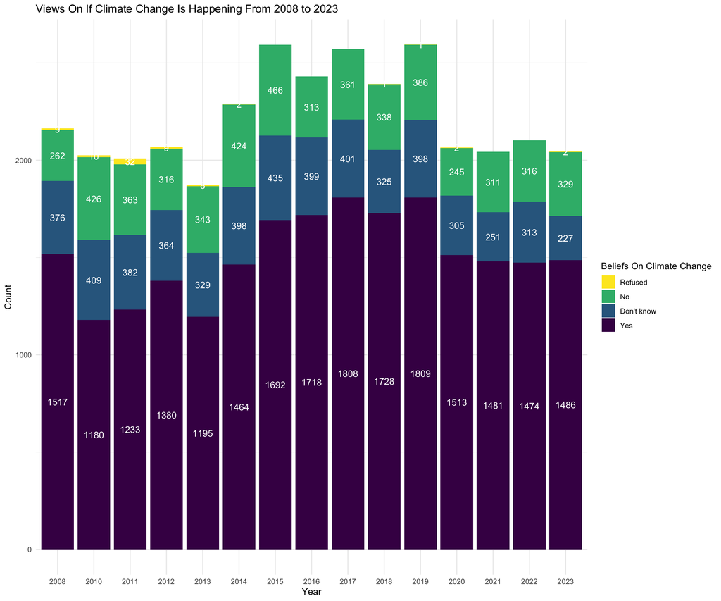

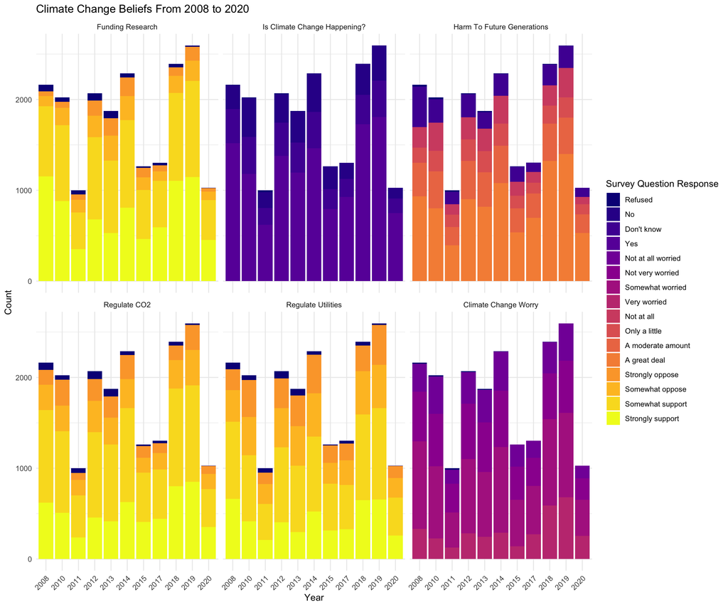

```
## `geom_line()`: Each group consists of only one observation.
## ℹ Do you need to adjust the group aesthetic?
```

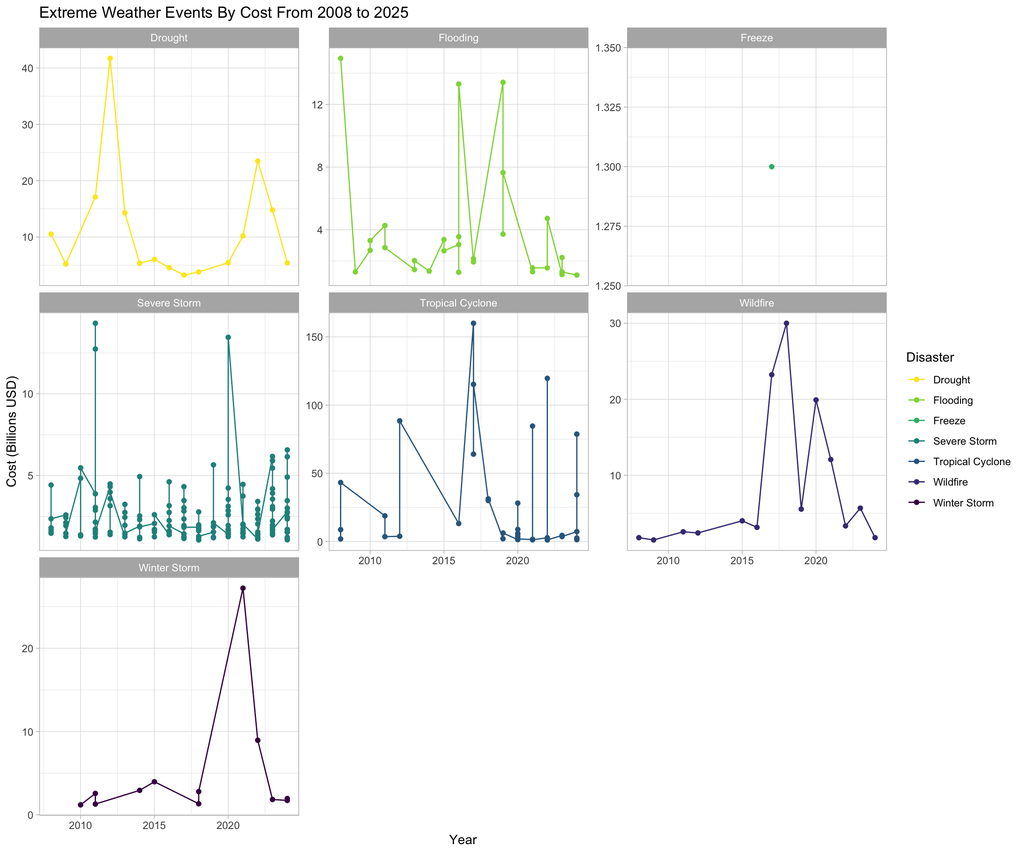

```
## `geom_line()`: Each group consists of only one observation.
## ℹ Do you need to adjust the group aesthetic?
```

[figure not shown]

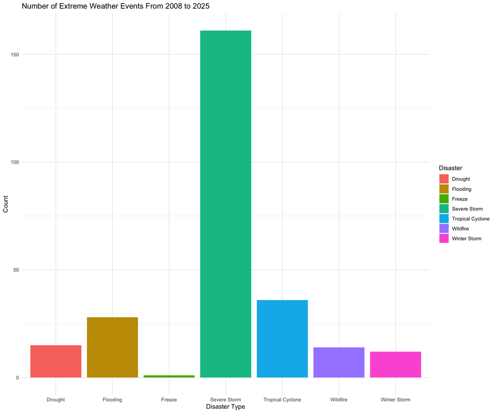

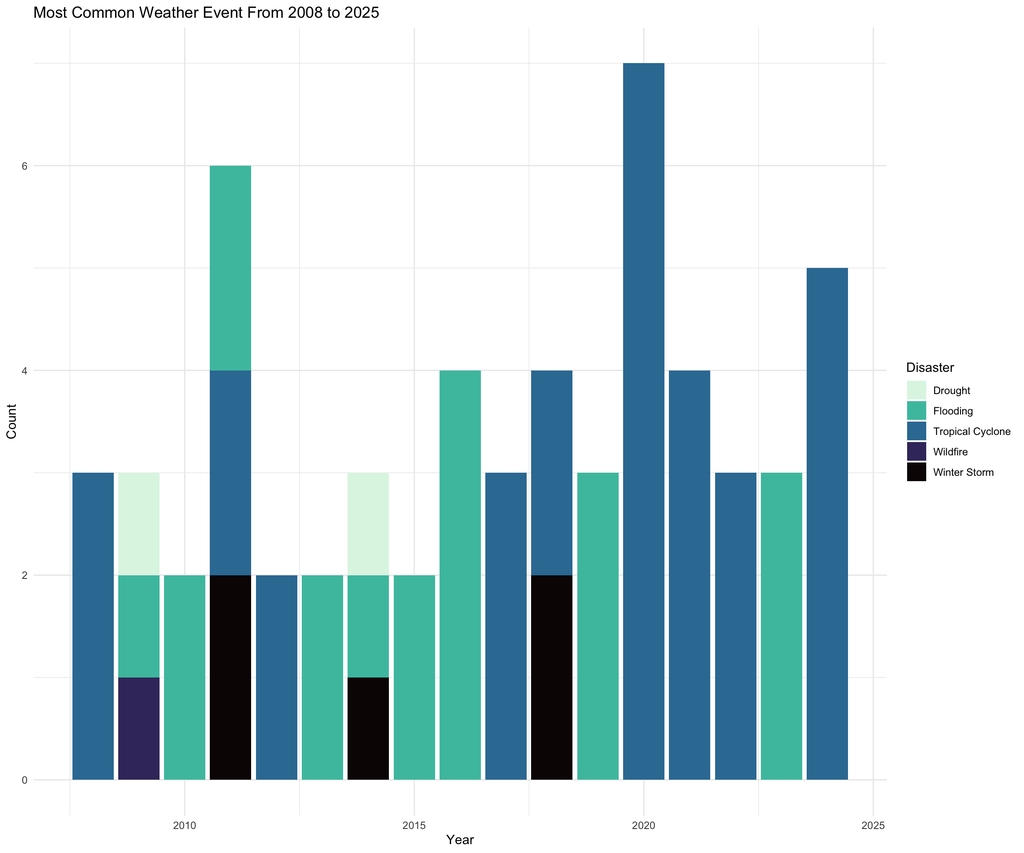

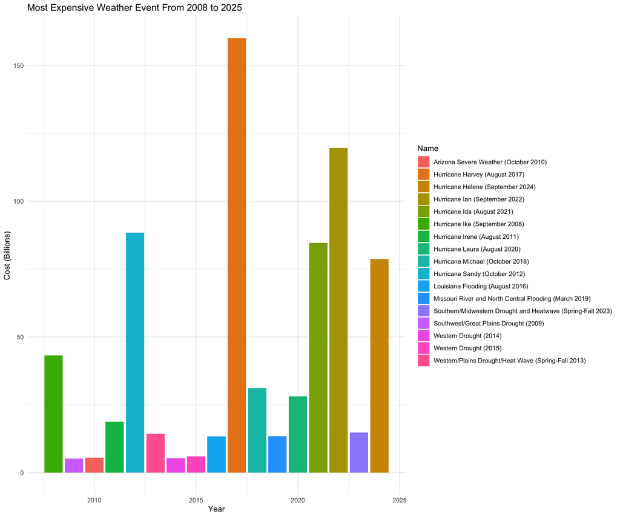

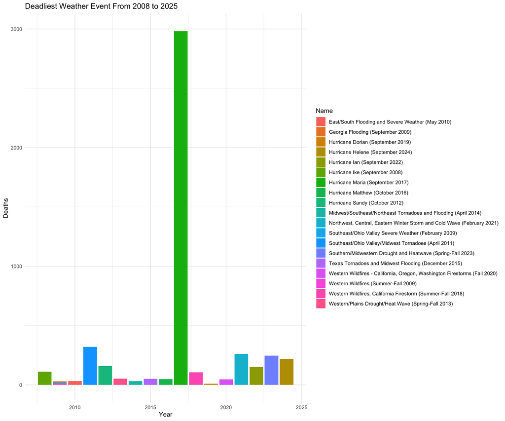

[figure not shown]

## Discussion

Some of the trends found in my project supported my hypothesis that climate change and risk perceptions would increase in years following an extreme weather event but then decrease in later years. interestingly, I didn’t account for the lag where responses in favor of regulations/funding, and extreme harm and worry steadily increased following years with extreme weather, in particular, years with the most damage done. Similar trends were seen in Visconti & Young, where they examined the effect of exposure to weather events like floods, hurricanes, severe storms, and wildfires on climate change beliefs and the impact on policy action. The authors of this study found that only wildfires showed a significant impact that was not long lasting, disappearing one year after exposure (Visconti et al., 2024).

One of the limitations of this study is that the climate change survey data from the Yale Program on Climate Change Communication & George Mason University Center for Climate Change is recorded from different respondents each year. The data is not tracked across years so there may be some years where more people respond skewing the data. This could make it appear that there are trends where some years center answers were given more than other but really it is just because there was a bigger sample that year. Another limitation is the weather date didn’t give much explanation into the extreme weather other than the name of the event, the type, the damage cost, and the deaths. It is also harder to assess the impact of extreme weather on a global scale because certain weather events like hurricanes and floods only happen in one geographical location so their impact in areas that are not affected might be less. It would be more meaningful to look at the impact at a state level but data like this is hard to obtain and difficult to do analysis on, I think this could be a good future direction for this project if there was more time as well as unlimited resources. I also think it would be interesting to examine demographics along with extreme weather and climate change perception to understand what communities might be impacted more by extreme weather.

In conclusion, some correlations between climate change perceptions like willingness to support research and regulations as well as views of future harm and worry show correlations with years where extreme weather events caused large amounts of costly damage and death. While it’s hard to tell whether these correlations have any significant meaning without further analysis, visual trends show an interesting relationship that warrants further exploration. According to NASA, since 1950, the frequency and intensity of heat extremes have increased and it’s primarily due to human-caused increase in greenhouse gas emissions. As the planet continues to warm, these events will only become more extreme and intense (NASA, 2024). It’s important to understand what may influence a persons perception of climate change, especially when it comes to motivating people to take action and vote. It’s also important in understanding how we can effectively communicate new research and findings about climate change in a depolarizing way (Yale School of The Environment, 2024). Climate change is no longer a distant threat, understanding what influences a persons beliefs and perceptions on climate change is important to providing effective solutions that will benefit all of us.

## Works Cited

1. What to know about Trump’s first executive actions on climate and environment. AP News https://apnews.com/article/trump-executive-orders-climate-change-environmental-policy-e4fb2b2495c0bcf880fab46605936b09 (2025).
2. The Link Between Climate Change and Extreme Weather. https://environment.yale.edu/news/article/link-between-climate-change-and-extreme-weather (2024).
3. Effects - NASA Science. https://science.nasa.gov/climate-change/effects/ (2022).
4. Trump Issues Executive Order on Climate Change | Sabin Center for Climate Change Law. https://climate.law.columbia.edu/content/trump-issues-executive-order-climate-change-0.
5. Severe Weather | National Centers for Environmental Information (NCEI). https://www.ncei.noaa.gov/products/severe-weather.
6. Climate change impacts | National Oceanic and Atmospheric Administration. https://www.noaa.gov/education/resource-collections/climate/climate-change-impacts.
7. Visconti, G. & Young, K. The effect of different extreme weather events on attitudes toward climate change. PLOS ONE 19, (2024).
8. Spence, A., Poortinga, W., Butler, C. & Pidgeon, N. F. Perceptions of climate change and willingness to save energy related to flood experience. Nature Climate Change 1, 46–49 (2011).
9. Poortinga, W., Demski, C. & Steentjes, K. Generational differences in climate-related beliefs, risk perceptions and emotions in the UK. Communications Earth & Environment 4, 229 (2023).
10. Mase, A. S., Gramig, B. M. & Prokopy, L. S. Climate change beliefs, risk perceptions, and adaptation behavior among Midwestern U.S. crop farmers. Climate Risk Management 15, 8–17 (2017).
11. Hai, Z. & Perlman, R. L. Extreme weather events and the politics of climate change attribution. Science Advances 8, eabo2190.
12. Gould, R. K., Shrum, T. R., Ramirez Harrington, D. & Iglesias, V. Experience with extreme weather events increases willingness-to-pay for climate mitigation policy. Global Environmental Change 85, 102795 (2024).
13. Fritz, L., Baum, C. M., Brutschin, E., Low, S. & Sovacool, B. K. Climate beliefs, climate technologies and transformation pathways: Contextualizing public perceptions in 22 countries. Global Environmental Change 87, 102880 (2024).
14. Dietz, T. Political events and public views on climate change. Climatic Change 161, 1–8 (2020).
15. Capstick, S., Whitmarsh, L., Poortinga, W., Pidgeon, N. & Upham, P. International trends in public perceptions of climate change over the past quarter century. WIREs Climate Change 6, 35–61 (2015).
16. Binelli, C., Loveless, M. & Schaffner, B. F. Explaining Perceptions of Climate Change in the US. Political Research Quarterly 76, 365–380 (2023).
17. Extreme Weather - NASA Science. https://science.nasa.gov/climate-change/extreme-weather/ (2023).
18. Funk, G. P., Alison Spencer, Alec Tyson and Cary. Why Some Americans Do Not See Urgency on Climate Change. Pew Research Center https://www.pewresearch.org/science/2023/08/09/why-some-americans-do-not-see-urgency-on-climate-change/ (2023).